# Business Analytics aplicado a datos bancarios

Juan Leal, Miguel Porras, Joaquín Loaces

26/05/2026

```r
knitr::opts_chunk$set(echo = TRUE)

options(repos = c(CRAN = "https://cloud.r-project.org"))

# ============================================================
# 0. Paquetes
# ============================================================

packages <- c(
  "tidyverse", "janitor", "skimr", "GGally",
  "tidymodels", "rpart.plot", "ranger", "kernlab",
  "cluster", "factoextra", "FactoMineR",
  "arules", "arulesViz", "scales", "vip", "pROC"
)

missing <- setdiff(packages, rownames(installed.packages()))
if (length(missing) > 0) install.packages(missing)

invisible(lapply(packages, library, character.only = TRUE))

theme_set(theme_minimal())
set.seed(123)
```

# 1 1. Introducción y objetivo de negocio

Este proyecto analiza una base de datos de campañas de marketing bancario. Cada fila representa un cliente contactado por el banco, junto con características personales, financieras y de la campaña. La variable objetivo es `deposit`, que indica si el cliente contrató o no un depósito.

Desde el punto de vista de Business Analytics, el objetivo no es únicamente construir un modelo predictivo, sino entender qué información permite mejorar la decisión de negocio: **priorizar clientes con mayor probabilidad de contratar un depósito en futuras campañas comerciales**.

El trabajo se estructura siguiendo la metodología CRISP-DM:

1. Comprensión del negocio.
2. Comprensión de los datos.
3. Preparación de los datos.
4. Modelado.
5. Evaluación.
6. Conclusiones y recomendaciones de negocio.

# 2 2. Carga y comprensión inicial de los datos

```r
# Cambiar la ruta si el CSV está en otra carpeta.
bank_raw <- read_csv("bank 2.csv", show_col_types = FALSE) |>
  clean_names()

bank <- bank_raw |>
  mutate(
    across(where(is.character), as.factor),
    deposit = factor(deposit, levels = c("no", "yes"))
  )

glimpse(bank)
```

```
## Rows: 11,162
## Columns: 17
## $ age       <dbl> 59, 56, 41, 55, 54, 42, 56, 60, 37, 28, 38, 30, 29, 46, 31, …
## $ job       <fct> admin., admin., technician, services, admin., management, ma…
## $ marital   <fct> married, married, married, married, married, single, married…
## $ education <fct> secondary, secondary, secondary, secondary, tertiary, tertia…
## $ default   <fct> no, no, no, no, no, no, no, no, no, no, no, no, no, no, no, …
## $ balance   <dbl> 2343, 45, 1270, 2476, 184, 0, 830, 545, 1, 5090, 100, 309, 1…
## $ housing   <fct> yes, no, yes, yes, no, yes, yes, yes, yes, yes, yes, yes, ye…
## $ loan      <fct> no, no, no, no, no, yes, yes, no, no, no, no, no, yes, no, n…
## $ contact   <fct> unknown, unknown, unknown, unknown, unknown, unknown, unknow…
## $ day       <dbl> 5, 5, 5, 5, 5, 5, 6, 6, 6, 6, 7, 7, 7, 7, 8, 8, 8, 8, 8, 8, …
## $ month     <fct> may, may, may, may, may, may, may, may, may, may, may, may, …
## $ duration  <dbl> 1042, 1467, 1389, 579, 673, 562, 1201, 1030, 608, 1297, 786,…
## $ campaign  <dbl> 1, 1, 1, 1, 2, 2, 1, 1, 1, 3, 1, 2, 4, 2, 2, 1, 3, 1, 2, 1, …
## $ pdays     <dbl> -1, -1, -1, -1, -1, -1, -1, -1, -1, -1, -1, -1, -1, -1, -1, …
## $ previous  <dbl> 0, 0, 0, 0, 0, 0, 0, 0, 0, 0, 0, 0, 0, 0, 0, 0, 0, 0, 0, 0, …
## $ poutcome  <fct> unknown, unknown, unknown, unknown, unknown, unknown, unknow…
## $ deposit   <fct> yes, yes, yes, yes, yes, yes, yes, yes, yes, yes, yes, yes, …
```

```r
# Dimensión del dataset
cat("Filas:", nrow(bank), "\n")
```

```
## Filas: 11162
```

```r
cat("Columnas:", ncol(bank), "\n")
```

```
## Columnas: 17
```

```r
# Valores perdidos
bank |>
  summarise(across(everything(), ~sum(is.na(.)))) |>
  pivot_longer(everything(), names_to = "variable", values_to = "missing") |>
  arrange(desc(missing))
```

```
## # A tibble: 17 × 2
##    variable  missing
##    <chr>       <int>
##  1 age             0
##  2 job             0
##  3 marital         0
##  4 education       0
##  5 default         0
##  6 balance         0
##  7 housing         0
##  8 loan            0
##  9 contact         0
## 10 day             0
## 11 month           0
## 12 duration        0
## 13 campaign        0
## 14 pdays           0
## 15 previous        0
## 16 poutcome        0
## 17 deposit         0
```

```r
# Distribución de la variable objetivo
bank |>
  count(deposit) |>
  mutate(prop = n / sum(n))
```

```
## # A tibble: 2 × 3
##   deposit     n  prop
##   <fct>   <int> <dbl>
## 1 no       5873 0.526
## 2 yes      5289 0.474
```

**Comentario inicial.** El dataset contiene variables numéricas y categóricas. No aparecen valores `NA`, pero sí existen categorías como `unknown` y valores especiales como `pdays = -1`, que indican que el cliente no había sido contactado previamente. Estos casos se tratarán explícitamente en la preparación de datos. Adicionalmente, cabe resaltar que la variable objetivo `deposit` no muestra un desbalanceo significativo entre sus dos clases (no: 53%, yes: 47%), lo cual es una ventaja, ya que, al implementar modelos predictivos esto favorece a que el modelo aprenda mejor, reduciendo un posible sesgo hacía una clase mayoritaria sin tener que utilizar técnicas de rebalanceo.

# 3 3. Análisis descriptivo completo

## 3.1 3.1 Variables numéricas

```r
num_vars <- bank |> select(where(is.numeric)) |> names()
cat("Variables numéricas:", paste(num_vars, collapse = ", "))
```

```
## Variables numéricas: age, balance, day, duration, campaign, pdays, previous
```

```r
bank |>
  select(all_of(num_vars)) |>
  skimr::skim()
```

Data summary

| Name | select(bank, all_of(num_v… |
| --- | --- |
| Number of rows | 11162 |
| Number of columns | 7 |
| _______________________ |  |
| Column type frequency: |  |
| numeric | 7 |
| ________________________ |  |
| Group variables | None |

**Variable type: numeric**

| skim_variable | n_missing | complete_rate | mean | sd | p0 | p25 | p50 | p75 | p100 | hist |
| --- | --- | --- | --- | --- | --- | --- | --- | --- | --- | --- |
| age | 0 | 1 | 41.23 | 11.91 | 18 | 32 | 39 | 49.00 | 95 | ▆▇▅▁▁ |
| balance | 0 | 1 | 1528.54 | 3225.41 | -6847 | 122 | 550 | 1708.00 | 81204 | ▇▁▁▁▁ |
| day | 0 | 1 | 15.66 | 8.42 | 1 | 8 | 15 | 22.00 | 31 | ▇▇▇▆▆ |
| duration | 0 | 1 | 371.99 | 347.13 | 2 | 138 | 255 | 496.00 | 3881 | ▇▁▁▁▁ |
| campaign | 0 | 1 | 2.51 | 2.72 | 1 | 1 | 2 | 3.00 | 63 | ▇▁▁▁▁ |
| pdays | 0 | 1 | 51.33 | 108.76 | -1 | -1 | -1 | 20.75 | 854 | ▇▁▁▁▁ |
| previous | 0 | 1 | 0.83 | 2.29 | 0 | 0 | 0 | 1.00 | 58 | ▇▁▁▁▁ |

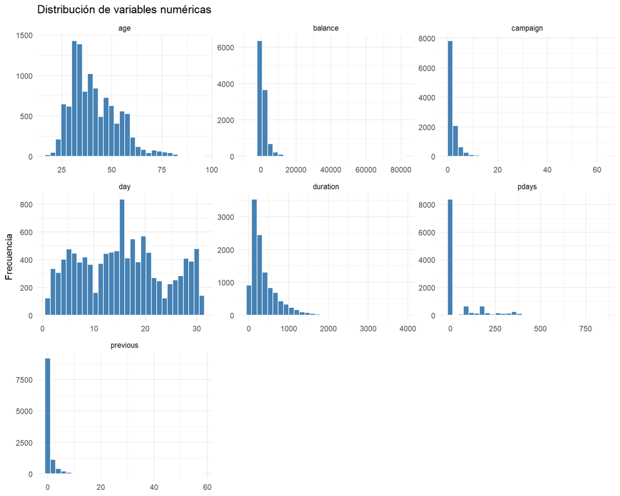

```r
bank |>
  select(all_of(num_vars)) |>
  pivot_longer(everything(), names_to = "variable", values_to = "value") |>
  ggplot(aes(value)) +
  geom_histogram(bins = 30, fill = "steelblue", color = "white") +
  facet_wrap(~ variable, scales = "free") +
  labs(title = "Distribución de variables numéricas", x = NULL, y = "Frecuencia")
```

**Interpretación:** Las distribuciones de las variables numéricas muestran que la mayoría presentan una fuerte asimetría positiva y presencia de valores atípicos. Variables como `balance`, `campaign`, `duration`, `pdays` y `previous` concentran gran parte de las observaciones en valores bajos, pero presentan colas hacia valores altos, lo que indica la existencia de clientes con comportamientos distintos al promedio. La variable `age` muestra una distribución más equilibrada, concentrándose principalmente entre los 30 y 50 años, mientras que day presenta una distribución relativamente uniforme a lo largo del mes, con un pico a mediados de mes.

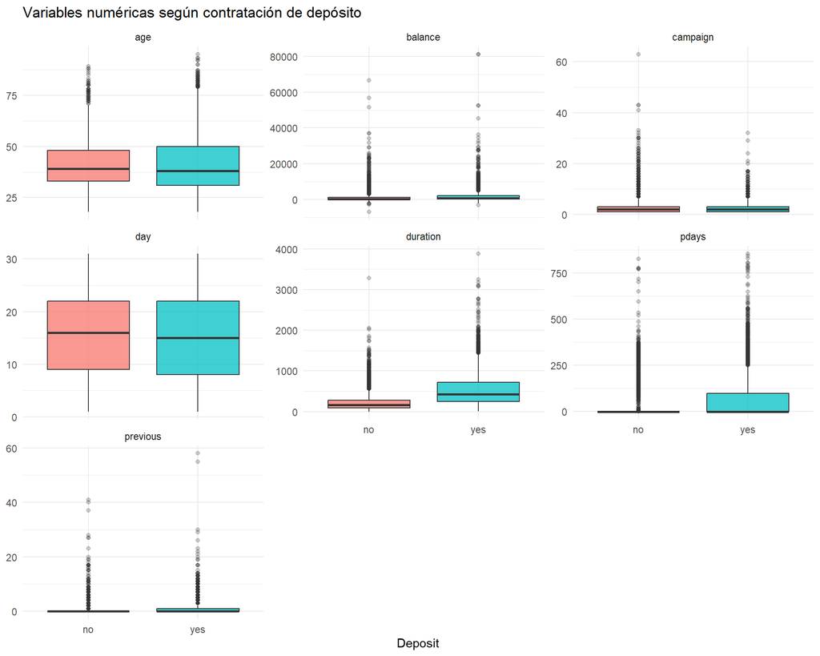

```r
bank |>
  pivot_longer(cols = all_of(num_vars), names_to = "variable", values_to = "value") |>
  ggplot(aes(deposit, value, fill = deposit)) +
  geom_boxplot(alpha = 0.75, outlier.alpha = 0.25) +
  facet_wrap(~ variable, scales = "free_y") +
  labs(title = "Variables numéricas según contratación de depósito", x = "Deposit", y = NULL) +
  theme(legend.position = "none")
```

**Interpretación:** En los diagramas de caja según la contratación del depósito (`deposit`), la variable `duration` muestra una diferencia clara entre clases, observándose llamadas considerablemente más largas en los clientes que sí contrataron el depósito, lo que sugiere una fuerte relación con la variable objetivo. También se aprecia que los clientes que aceptaron el depósito tienden a tener mayores valores de `pdays` y `previous`, indicando una mayor interacción previa con campañas del banco. Por otro lado, `campaign` presenta medianas similares entre clases, aunque con numerosos valores extremos, mientras que `age` y `balance` muestran diferencias moderadas, sugiriendo una influencia menos determinante.

## 3.2 3.2 Variables categóricas

```r
cat_vars <- bank |> select(where(is.factor)) |> names()
cat("Variables categóricas:", paste(cat_vars, collapse = ", "))
```

```
## Variables categóricas: job, marital, education, default, housing, loan, contact, month, poutcome, deposit
```

```r
cat_summary <- bank |>
  select(all_of(cat_vars)) |>
  pivot_longer(everything(), names_to = "variable", values_to = "category") |>
  count(variable, category, sort = TRUE) |>
  group_by(variable) |>
  mutate(prop = n / sum(n)) |>
  ungroup()

cat_summary
```

```
## # A tibble: 46 × 4
##    variable  category      n  prop
##    <chr>     <fct>     <int> <dbl>
##  1 default   no        10994 0.985
##  2 loan      no         9702 0.869
##  3 poutcome  unknown    8326 0.746
##  4 contact   cellular   8042 0.720
##  5 marital   married    6351 0.569
##  6 housing   no         5881 0.527
##  7 deposit   no         5873 0.526
##  8 education secondary  5476 0.491
##  9 deposit   yes        5289 0.474
## 10 housing   yes        5281 0.473
## # ℹ 36 more rows
```

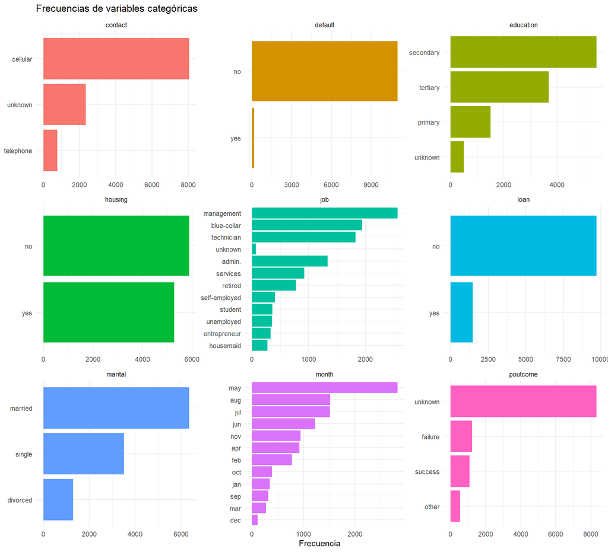

```r
cat_summary |>
  filter(variable != "deposit") |>
  ggplot(aes(fct_reorder(category, n), n, fill = variable)) +
  geom_col(show.legend = FALSE) +
  coord_flip() +
  facet_wrap(~ variable, scales = "free") +
  labs(title = "Frecuencias de variables categóricas", x = NULL, y = "Frecuencia")
```

**Interpretación:** Las gráficas de frecuencias de las variables categóricas permiten observar una distribución desigual entre muchas de las categorías del dataset. En `contact` predomina claramente el uso de teléfonos móviles (cellular). La variable `default` muestra que casi ningún cliente tiene historial de impago, indicando un fuerte desbalance en esta categoría. En `education`, predominan los niveles de educación secundaria y terciaria, mientras que `job` presenta una mayor representación de perfiles de management, blue-collar y técnicos. Respecto a variables financieras, la mayoría de clientes no poseen préstamos personales (`loan`) y la distribución de hipotecas (`housing`) es relativamente equilibrada. En `marital`, predominan claramente los clientes casados, seguidos por solteros. La variable `month` evidencia que la mayor parte de los contactos se realizaron en mayo, seguido de agosto y julio, lo que sugiere una fuerte concentración temporal de las campañas en épocas en torno al verano/fin del curso académico. Finalmente, en `poutcome` destaca que la mayoría de registros aparecen como unknown, indicando que en muchos casos no existía información sobre campañas anteriores, mientras que los resultados exitosos y fallidos representan una proporción mucho menor del conjunto de datos.

## 3.3 3.3 Relación entre variables categóricas y `deposit`

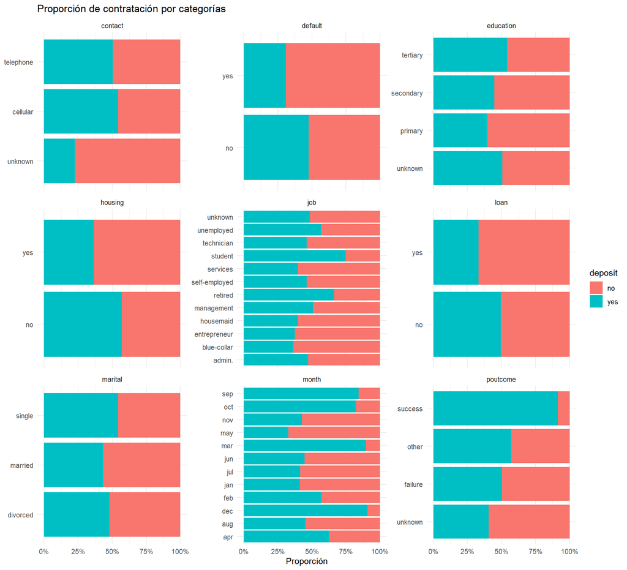

```r
bank |>
  select(all_of(setdiff(cat_vars, "deposit")), deposit) |>
  pivot_longer(cols = -deposit, names_to = "variable", values_to = "category") |>
  count(variable, category, deposit) |>
  group_by(variable, category) |>
  mutate(prop = n / sum(n)) |>
  ungroup() |>
  ggplot(aes(fct_reorder(category, prop), prop, fill = deposit)) +
  geom_col(position = "fill") +
  coord_flip() +
  facet_wrap(~ variable, scales = "free_y") +
  scale_y_continuous(labels = percent_format()) +
  labs(
    title = "Proporción de contratación por categorías",
    x = NULL,
    y = "Proporción"
  )
```

**Interpretación:** Estas gráficas permiten observar cómo la distribución entre clientes que contrataron (yes) y no contrataron (no) el depósito varía dentro de cada categoría. Aunque en el apartado anterior se observó que categorías como *cellular*, *management* o *secondary* eran las más frecuentes, aquí se aprecia que la frecuencia de aparición no implica necesariamente una mayor tasa de contratación. Por ejemplo, aunque *management* y *blue-collar* son de los grupos laborales más numerosos, los perfiles con mayor proporción de contratación son *student* y *retired*. Del mismo modo, la categoría *unknown* en `contact` y `poutcome`, que ya destacaba por tener una presencia elevada, presenta una menor proporción de éxito respecto a categorías con información más específica. También se confirma que los clientes sin préstamos (`loan` = no) ni hipoteca (`housing` = no) muestran una tendencia más favorable a contratar el depósito. En la variable temporal `month`,mayo concentraba el mayor número de contactos pero se observa que no es el mes con mejor tasa de conversión, mientras que meses menos frecuentes como septiembre y octubre (meses post-verano) o diciembre (navidades) presentan porcentajes de contratación superiores. Finalmente, la variable `poutcome` vuelve a destacar como una de las más influyentes, ya que los clientes con campañas previas exitosas (*success*), aunque menos frecuentes, muestran una probabilidad muy alta de contratar nuevamente el depósito.

# 4 4. Preparación de datos

En esta etapa se realiza un proceso de transformación y enriquecimiento del dataset con el objetivo de mejorar la interpretabilidad de las variables y facilitar posteriores análisis estadísticos y modelados.

En primer lugar, la variable `pdays` es modificada para tratar adecuadamente el valor especial `-1`, utilizado en el dataset para indicar que un cliente nunca había sido contactado previamente.

A partir de esta información se crea la nueva variable categórica `previous_contacted`, que distingue entre clientes previamente contactados (`yes`) y clientes sin contacto previo (`no`).

Además, se genera la variable `pdays_clean`, donde los valores `-1` son reemplazados por valores nulos (`NA`), evitando que el modelo interprete incorrectamente dichos valores como una cantidad real de días.

Posteriormente, varias variables numéricas continuas son discretizadas en intervalos categóricos más interpretables.

La variable `age` se transforma en `age_group`, agrupando los clientes en perfiles de edad (`young`, `adult`, `middle_age` y `senior`).

La variable `balance` se convierte en `balance_group`, clasificando el balance bancario en niveles desde bajo hasta alto mediante cuartiles.

De forma similar, `duration` se transforma en `duration_group`, agrupando la duración de las llamadas en diferentes categorías temporales.

Finalmente, las variables `campaign` y `previous` son convertidas en `campaign_group` y `previous_group`, respectivamente, permitiendo distinguir entre clientes con pocos o muchos contactos durante campañas actuales y anteriores. Estas transformaciones permiten simplificar el análisis de patrones de comportamiento y mejorar la interpretabilidad de los resultados obtenidos posteriormente.

```r
bank_prep <- bank |>
  mutate(
    # pdays = -1 indica que el cliente no fue contactado previamente.
    previous_contacted = if_else(pdays == -1, "no", "yes"),
    previous_contacted = factor(previous_contacted),
    pdays_clean = if_else(pdays == -1, NA_real_, as.numeric(pdays)),

    # Variables discretizadas útiles para reglas de asociación.
    age_group = cut(
      age,
      breaks = c(-Inf, 30, 45, 60, Inf),
      labels = c("young", "adult", "middle_age", "senior")
    ),
    balance_group = cut(
      balance,
      breaks = quantile(balance, probs = c(0, .25, .5, .75, 1), na.rm = TRUE),
      include.lowest = TRUE,
      labels = c("low", "medium_low", "medium_high", "high")
    ),
    duration_group = cut(
      duration,
      breaks = quantile(duration, probs = c(0, .25, .5, .75, 1), na.rm = TRUE),
      include.lowest = TRUE,
      labels = c("short", "medium_short", "medium_long", "long")
    ),
    campaign_group = cut(
      campaign,
      breaks = c(-Inf, 1, 2, 4, Inf),
      labels = c("one", "two", "three_four", "many")
    ),
    previous_group = cut(
      previous,
      breaks = c(-Inf, 0, 1, 3, Inf),
      labels = c("none", "one", "two_three", "many")
    )
  )

bank_prep |> select(age, age_group, balance, balance_group, duration, duration_group, pdays, previous_contacted, pdays_clean) |> head()
```

```
## # A tibble: 6 × 9
##     age age_group  balance balance_group duration duration_group pdays
##   <dbl> <fct>        <dbl> <fct>            <dbl> <fct>          <dbl>
## 1    59 middle_age    2343 high              1042 long              -1
## 2    56 middle_age      45 low               1467 long              -1
## 3    41 adult         1270 medium_high       1389 long              -1
## 4    55 middle_age    2476 high               579 long              -1
## 5    54 middle_age     184 medium_low         673 long              -1
## 6    42 adult            0 low                562 long              -1
## # ℹ 2 more variables: previous_contacted <fct>, pdays_clean <dbl>
```

# 5 5. Representaciones alternativas de los datos

El dataset original combina variables numéricas y categóricas. Por eso no existe una única representación correcta. Cada técnica necesita una codificación distinta.

## 5.1 5.1 Representación tabular original

```r
rep_original <- bank_prep
rep_original |> glimpse()
```

```
## Rows: 11,162
## Columns: 24
## $ age                <dbl> 59, 56, 41, 55, 54, 42, 56, 60, 37, 28, 38, 30, 29,…
## $ job                <fct> admin., admin., technician, services, admin., manag…
## $ marital            <fct> married, married, married, married, married, single…
## $ education          <fct> secondary, secondary, secondary, secondary, tertiar…
## $ default            <fct> no, no, no, no, no, no, no, no, no, no, no, no, no,…
## $ balance            <dbl> 2343, 45, 1270, 2476, 184, 0, 830, 545, 1, 5090, 10…
## $ housing            <fct> yes, no, yes, yes, no, yes, yes, yes, yes, yes, yes…
## $ loan               <fct> no, no, no, no, no, yes, yes, no, no, no, no, no, y…
## $ contact            <fct> unknown, unknown, unknown, unknown, unknown, unknow…
## $ day                <dbl> 5, 5, 5, 5, 5, 5, 6, 6, 6, 6, 7, 7, 7, 7, 8, 8, 8, …
## $ month              <fct> may, may, may, may, may, may, may, may, may, may, m…
## $ duration           <dbl> 1042, 1467, 1389, 579, 673, 562, 1201, 1030, 608, 1…
## $ campaign           <dbl> 1, 1, 1, 1, 2, 2, 1, 1, 1, 3, 1, 2, 4, 2, 2, 1, 3, …
## $ pdays              <dbl> -1, -1, -1, -1, -1, -1, -1, -1, -1, -1, -1, -1, -1,…
## $ previous           <dbl> 0, 0, 0, 0, 0, 0, 0, 0, 0, 0, 0, 0, 0, 0, 0, 0, 0, …
## $ poutcome           <fct> unknown, unknown, unknown, unknown, unknown, unknow…
## $ deposit            <fct> yes, yes, yes, yes, yes, yes, yes, yes, yes, yes, y…
## $ previous_contacted <fct> no, no, no, no, no, no, no, no, no, no, no, no, no,…
## $ pdays_clean        <dbl> NA, NA, NA, NA, NA, NA, NA, NA, NA, NA, NA, NA, NA,…
## $ age_group          <fct> middle_age, middle_age, adult, middle_age, middle_a…
## $ balance_group      <fct> high, low, medium_high, high, medium_low, low, medi…
## $ duration_group     <fct> long, long, long, long, long, long, long, long, lon…
## $ campaign_group     <fct> one, one, one, one, two, two, one, one, one, three_…
## $ previous_group     <fct> none, none, none, none, none, none, none, none, non…
```

## 5.2 5.2 Representación numérica escalada

Esta representación transforma el conjunto de datos a un formato completamente numérico utilizando únicamente variables cuantitativas relevantes del dataset, como la edad, el balance bancario, la duración de la llamada o el número de contactos realizados. Previamente, la variable `pdays` es ajustada reemplazando el valor especial `-1` por `0`, evitando así problemas durante el proceso de escalado. Posteriormente, todas las variables son estandarizadas mediante un proceso de escalado, de forma que cada una pase a tener media cercana a 0 y desviación estándar cercana a 1. Esto evita que variables con rangos muy grandes, como `balance` o `duration`, dominen sobre otras durante el entrenamiento de modelos.

Este tipo de representación es especialmente útil en algoritmos sensibles a la escala de los datos, como regresión logística, redes neuronales, máquinas de soporte vectorial (SVM), clustering o métodos basados en distancias como K-Means o KNN. Además, el escalado mejora la estabilidad numérica y acelera la convergencia de muchos algoritmos de optimización utilizados en Machine Learning.

```r
rep_numeric <- bank_prep |>
  select(age, balance, day, duration, campaign, pdays, previous) |>
  mutate(pdays = if_else(pdays == -1, 0, pdays))

rep_numeric_scaled <- scale(rep_numeric)
summary(rep_numeric_scaled)
```

```
##       age             balance              day              duration
##  Min.   :-1.9501   Min.   :-2.59673   Min.   :-1.74071   Min.   :-1.0659
##  1st Qu.:-0.7749   1st Qu.:-0.43608   1st Qu.:-0.90943   1st Qu.:-0.6741
##  Median :-0.1873   Median :-0.30338   Median :-0.07814   Median :-0.3370
##  Mean   : 0.0000   Mean   : 0.00000   Mean   : 0.00000   Mean   : 0.0000
##  3rd Qu.: 0.6520   3rd Qu.: 0.05564   3rd Qu.: 0.75314   3rd Qu.: 0.3572
##  Max.   : 4.5133   Max.   :24.70240   Max.   : 1.82193   Max.   :10.1087
##     campaign           pdays            previous
##  Min.   :-0.5541   Min.   :-0.4804   Min.   :-0.36324
##  1st Qu.:-0.5541   1st Qu.:-0.4804   1st Qu.:-0.36324
##  Median :-0.1868   Median :-0.4804   Median :-0.36324
##  Mean   : 0.0000   Mean   : 0.0000   Mean   : 0.00000
##  3rd Qu.: 0.1806   3rd Qu.:-0.2890   3rd Qu.: 0.07306
##  Max.   :22.2226   Max.   : 7.3978   Max.   :24.94209
```

## 5.3 5.3 Representación con variables dummy

Esta representación transforma el dataset a un formato completamente numérico utilizando codificación *dummy* o *one-hot encoding* para las variables categóricas. A partir de todas las variables predictoras del conjunto de datos, cada categoría posible de variables como `job`, `education`, `marital` o `month` se convierte en una nueva variable binaria que indica la presencia o ausencia de dicha categoría en cada observación. De esta manera, el dataset final queda compuesto únicamente por variables numéricas, permitiendo que algoritmos de Machine Learning que no pueden trabajar directamente con texto o factores categóricos puedan utilizar correctamente la información.

Además, durante el proceso se eliminan variables con varianza nula o prácticamente constante, ya que no aportan información útil a los modelos, y posteriormente todas las variables numéricas son normalizadas para que tengan escalas comparables. Esta representación es especialmente útil en modelos como regresión logística, redes neuronales, SVM o métodos basados en distancias, donde las variables categóricas deben convertirse previamente a formato numérico. Aunque este enfoque incrementa considerablemente el número de variables del dataset, permite preservar la información completa de cada categoría sin introducir relaciones ordinales artificiales entre ellas.

```r
dummy_recipe <- recipe(deposit ~ ., data = bank_prep |> select(-pdays_clean)) |>
  step_dummy(all_nominal_predictors()) |>
  step_zv(all_predictors()) |>
  step_normalize(all_numeric_predictors())

dummy_prep <- prep(dummy_recipe)
rep_dummy <- bake(dummy_prep, new_data = NULL)

glimpse(rep_dummy)
```

```
## Rows: 11,162
## Columns: 59
## $ age                         <dbl> 1.49143807, 1.23962013, -0.01946953, 1.155…
## $ balance                     <dbl> 0.25251383, -0.45995300, -0.08015671, 0.29…
## $ day                         <dbl> -1.2656889, -1.2656889, -1.2656889, -1.265…
## $ duration                    <dbl> 1.9301394, 3.1544703, 2.9297696, 0.5963390…
## $ campaign                    <dbl> -0.5541435, -0.5541435, -0.5541435, -0.554…
## $ pdays                       <dbl> -0.4811625, -0.4811625, -0.4811625, -0.481…
## $ previous                    <dbl> -0.3632436, -0.3632436, -0.3632436, -0.363…
## $ deposit                     <fct> yes, yes, yes, yes, yes, yes, yes, yes, ye…
## $ job_blue.collar             <dbl> -0.4592089, -0.4592089, -0.4592089, -0.459…
## $ job_entrepreneur            <dbl> -0.1739895, -0.1739895, -0.1739895, -0.173…
## $ job_housemaid               <dbl> -0.1586287, -0.1586287, -0.1586287, -0.158…
## $ job_management              <dbl> -0.5463371, -0.5463371, -0.5463371, -0.546…
## $ job_retired                 <dbl> -0.2737083, -0.2737083, -0.2737083, -0.273…
```

[output cut: 46 more lines]

```r
dim(rep_dummy)
```

```
## [1] 11162    59
```

```r
rep_dummy |> select(1:8) |> head()
```

```
## # A tibble: 6 × 8
##       age balance   day duration campaign  pdays previous deposit
##     <dbl>   <dbl> <dbl>    <dbl>    <dbl>  <dbl>    <dbl> <fct>
## 1  1.49    0.253  -1.27    1.93    -0.554 -0.481   -0.363 yes
## 2  1.24   -0.460  -1.27    3.15    -0.554 -0.481   -0.363 yes
## 3 -0.0195 -0.0802 -1.27    2.93    -0.554 -0.481   -0.363 yes
## 4  1.16    0.294  -1.27    0.596   -0.554 -0.481   -0.363 yes
## 5  1.07   -0.417  -1.27    0.867   -0.187 -0.481   -0.363 yes
## 6  0.0645 -0.474  -1.27    0.547   -0.187 -0.481   -0.363 yes
```

## 5.4 5.4 Representación transaccional para reglas de asociación

Esta representación transforma el dataset a un formato transaccional orientado al descubrimiento de patrones y reglas de asociación entre características de los clientes y la contratación del depósito bancario. Para ello, se seleccionan principalmente variables categóricas y variables previamente discretizadas, como `age_group`, `balance_group`, `duration_group`, `campaign_group` y `previous_group`, junto con otras variables cualitativas originales como `job`, `education`, `marital` o `poutcome`. Todas las variables son convertidas explícitamente a factores categóricos para que cada valor posible pueda interpretarse como un “ítem” dentro de una transacción.

Posteriormente, cada registro del dataset es transformado a un formato de transacciones, donde cada cliente queda representado como un conjunto de características categóricas simultáneas. Este tipo de representación es especialmente útil en técnicas de minería de datos como el algoritmo Apriori o FP-Growth, cuyo objetivo es identificar asociaciones frecuentes entre variables, por ejemplo detectar perfiles de clientes con alta probabilidad de contratar un depósito. A diferencia de representaciones orientadas a modelos predictivos numéricos, el enfoque transaccional prioriza la interpretabilidad y la extracción de reglas comprensibles para el análisis de comportamiento y toma de decisiones de negocio.

```r
trans_data <- bank_prep |>
  select(
    deposit, age_group, job, marital, education, default, housing, loan,
    contact, month, poutcome, previous_contacted,
    balance_group, duration_group, campaign_group, previous_group
  ) |>
  mutate(across(everything(), as.factor))

trans <- as(trans_data, "transactions")
summary(trans)
```

```
## transactions as itemMatrix in sparse format with
##  11162 rows (elements/itemsets/transactions) and
##  68 columns (items) and a density of 0.2352941
##
## most frequent items:
##            default=no               loan=no      poutcome=unknown
##                 10994                  9702                  8326
## previous_contacted=no   previous_group=none               (Other)
##                  8324                  8324                132922
##
## element (itemset/transaction) length distribution:
## sizes
##    16
## 11162
##
##    Min. 1st Qu.  Median    Mean 3rd Qu.    Max.
##      16      16      16      16      16      16
##
## includes extended item information - examples:
##            labels variables levels
## 1      deposit=no   deposit     no
## 2     deposit=yes   deposit    yes
## 3 age_group=young age_group  young
##
## includes extended transaction information - examples:
##   transactionID
## 1             1
## 2             2
## 3             3
```

## 5.5 5.5 Representación mediante kernel gaussiano

Esta representación utiliza un kernel gaussiano para medir la similitud entre observaciones del dataset en un espacio de mayor dimensionalidad. En lugar de comparar directamente los valores originales de las variables, el kernel transforma las distancias entre clientes en una matriz de similitud, donde valores altos indican clientes con características parecidas y valores bajos representan perfiles más diferentes. Posteriormente, mediante una descomposición espectral de esta matriz, los datos son proyectados en dos coordenadas principales que permiten visualizar su estructura interna en un plano bidimensional.

Para evitar construir una matriz de Gram demasiado grande, se toma una muestra. La matriz completa tendría más de once mil filas y columnas, lo que puede ser innecesario para una visualización exploratoria.

```r
pairwise_sqdist <- function(X, Z = NULL) {
  X <- as.matrix(X)
  if (is.null(Z)) Z <- X else Z <- as.matrix(Z)
  XX <- rowSums(X * X)
  ZZ <- rowSums(Z * Z)
  outer(XX, ZZ, "+") - 2 * (X %*% t(Z))
}

kernel_gauss <- function(X, Z = NULL, sigma = 1) {
  exp(-pairwise_sqdist(X, Z) / (2 * sigma^2))
}
```

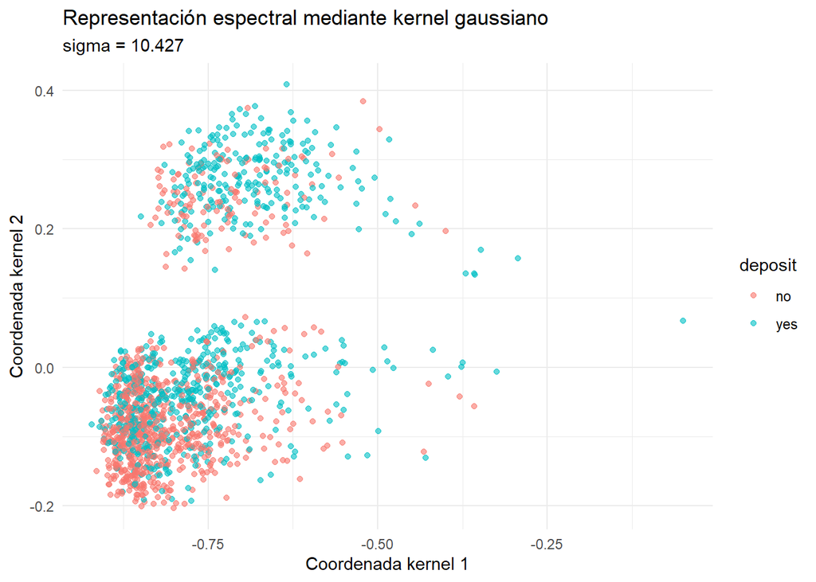

```r
set.seed(123)
idx_kernel <- sample(seq_len(nrow(rep_dummy)), size = min(1500, nrow(rep_dummy)))
X_kernel <- rep_dummy |>
  select(-deposit) |>
  slice(idx_kernel) |>
  as.matrix()

y_kernel <- rep_dummy |>
  slice(idx_kernel) |>
  pull(deposit)

# Heurística: sigma como mediana de distancias en una submuestra.
dist_sample <- dist(X_kernel[sample(seq_len(nrow(X_kernel)), min(300, nrow(X_kernel))), ])
sigma_med <- median(as.numeric(dist_sample))

K <- kernel_gauss(X_kernel, sigma = sigma_med)
K <- (K + t(K)) / 2

ev <- eigen(K, symmetric = TRUE)
coords_kernel <- tibble(
  coord1 = ev$vectors[, 1] * sqrt(pmax(ev$values[1], 0)),
  coord2 = ev$vectors[, 2] * sqrt(pmax(ev$values[2], 0)),
  deposit = y_kernel
)

ggplot(coords_kernel, aes(coord1, coord2, color = deposit)) +
  geom_point(alpha = 0.6) +
  labs(
    title = "Representación espectral mediante kernel gaussiano",
    subtitle = paste("sigma =", round(sigma_med, 3)),
    x = "Coordenada kernel 1",
    y = "Coordenada kernel 2"
  )
```

En la representación obtenida se observa la aparición de agrupaciones parciales entre clientes que contrataron el depósito (`yes`) y aquellos que no (`no`), aunque ambas clases siguen presentando cierto solapamiento. Esto indica que existen patrones no lineales en los datos que no son fácilmente visibles mediante representaciones lineales tradicionales. Sin embargo, la separación entre clases no es completamente clara, lo que refleja la complejidad del problema y la influencia simultánea de múltiples variables.

Este tipo de representación resulta útil para detectar estructuras ocultas, relaciones no lineales y posibles agrupamientos en datasets complejos. Además, constituye la base de métodos avanzados como máquinas de soporte vectorial con kernels (Kernel SVM), clustering espectral o técnicas de reducción de dimensionalidad no lineal. Entre sus principales limitaciones destacan el elevado coste computacional al trabajar con matrices de similitud grandes y la sensibilidad al parámetro `sigma`, cuyo valor determina el nivel de vecindad considerado entre observaciones y puede afectar significativamente a la calidad de la representación obtenida.

# 6 6. Distancias para datos mixtos

## 6.1 6.1 Distancia euclídea sobre variables numéricas

La distancia euclídea mide la similitud entre observaciones calculando la distancia geométrica entre clientes en el espacio formado por las variables numéricas escaladas. En este caso, cada cliente queda representado como un punto multidimensional definido por variables como edad, balance bancario, duración de la llamada o número de contactos, y la distancia refleja qué tan parecidos o diferentes son entre sí.

```r
set.seed(123)
idx_dist <- sample(seq_len(nrow(bank_prep)), size = min(1500, nrow(bank_prep)))

X_num_sample <- rep_numeric_scaled[idx_dist, ]
dist_euclidean <- dist(X_num_sample, method = "euclidean")
summary(as.numeric(dist_euclidean))
```

```
##     Min.  1st Qu.   Median     Mean  3rd Qu.     Max.
##  0.05964  2.19347  3.00194  3.23014  3.89744 27.26704
```

Los resultados obtenidos muestran que la mayoría de las distancias se concentran entre valores moderados, con una mediana cercana a 3 y un promedio de 3.23, lo que indica que gran parte de los clientes presentan perfiles relativamente similares tras el escalado de variables. Sin embargo, la existencia de distancias máximas muy elevadas sugiere la presencia de clientes atípicos o perfiles considerablemente distintos del resto. Este tipo de distancia es especialmente útil en algoritmos basados en proximidad, como KNN, clustering o métodos de reducción de dimensionalidad, aunque puede verse afectada por valores extremos y por la alta dimensionalidad de los datos.

## 6.2 6.2 Distancia de Manhattan

La distancia Manhattan mide la diferencia entre observaciones sumando las diferencias absolutas entre cada una de las variables numéricas, en lugar de calcular la distancia geométrica directa como ocurre con la distancia euclídea. Este enfoque puede interpretarse como la distancia recorrida siguiendo una cuadrícula, avanzando únicamente en cada dimensión de forma independiente.

```r
dist_manhattan <- dist(X_num_sample, method = "manhattan")
summary(as.numeric(dist_manhattan))
```

```
##     Min.  1st Qu.   Median     Mean  3rd Qu.     Max.
##  0.08131  3.91010  5.56790  5.99214  7.56155 44.74115
```

Los resultados muestran valores medios y medianos superiores a los obtenidos con la distancia euclídea, lo cual es esperable debido a la forma en que se agregan las diferencias entre variables. La mayoría de las distancias se concentran en rangos moderados, aunque nuevamente aparecen valores máximos elevados que indican la existencia de clientes con perfiles muy diferentes al resto del dataset. La distancia Manhattan suele ser más robusta frente a valores extremos y puede comportarse mejor en espacios de alta dimensionalidad, por lo que resulta útil en algoritmos de clustering, KNN y análisis de similitud cuando se desea reducir la influencia de grandes desviaciones en variables individuales.

## 6.3 6.3 Distancia de Gower para variables mixtas

La distancia de Gower permite medir similitud entre observaciones cuando el dataset contiene simultáneamente variables numéricas y categóricas, como ocurre en este caso con variables financieras, demográficas y de comportamiento. A diferencia de las distancias euclídea y Manhattan, que únicamente se aplicaron sobre variables numéricas escaladas, la distancia de Gower combina distintos tipos de variables dentro de una misma medida de disimilitud, normalizando automáticamente las contribuciones de cada característica. Esto permite incorporar información categórica importante, como el tipo de trabajo, nivel educativo o tipo de contacto, sin necesidad de transformarlas previamente a un espacio completamente numérico.

```r
X_mixed_sample <- bank_prep |>
  select(age, job, marital, education, default, balance, housing, loan,
         contact, campaign, previous_contacted, poutcome, deposit) |>
  slice(idx_dist)

dist_gower <- daisy(X_mixed_sample |> select(-deposit), metric = "gower")
summary(as.numeric(dist_gower))
```

```
##    Min. 1st Qu.  Median    Mean 3rd Qu.    Max.
##  0.0000  0.2709  0.3571  0.3620  0.4447  0.8569
```

Los resultados muestran distancias comprendidas entre 0 y aproximadamente 0.86, con una media cercana a 0.36, indicando que la mayoría de los clientes presentan un grado moderado de similitud entre sí cuando se consideran conjuntamente variables numéricas y categóricas. A diferencia de las distancias euclídea y Manhattan, cuyos valores podían alcanzar magnitudes muy elevadas debido a la acumulación de diferencias numéricas, la distancia de Gower queda acotada en un rango mucho más interpretable, facilitando la comparación entre observaciones. Este tipo de distancia resulta especialmente útil en datasets heterogéneos como el de marketing bancario, ya que preserva la información de distintos tipos de variables y suele utilizarse en clustering, análisis de similitud y técnicas exploratorias sobre datos mixtos.

# 7 7. Reglas de asociación

El dataset no es una cesta de compra natural, pero puede transformarse en una base transaccional donde cada cliente queda representado por un conjunto de atributos discretizados. La unidad de análisis es el cliente contactado por la campaña.

```r
rules_yes <- apriori(
  trans,
  parameter = list(supp = 0.02, conf = 0.50, minlen = 2, maxlen = 5, target = "rules"),
  appearance = list(rhs = "deposit=yes", default = "lhs")
)
```

```
## Apriori
##
## Parameter specification:
##  confidence minval smax arem  aval originalSupport maxtime support minlen
##         0.5    0.1    1 none FALSE            TRUE       5    0.02      2
##  maxlen target  ext
##       5  rules TRUE
##
## Algorithmic control:
##  filter tree heap memopt load sort verbose
##     0.1 TRUE TRUE  FALSE TRUE    2    TRUE
##
## Absolute minimum support count: 223
##
## set item appearances ...[1 item(s)] done [0.00s].
## set transactions ...[68 item(s), 11162 transaction(s)] done [0.01s].
## sorting and recoding items ... [65 item(s)] done [0.00s].
## creating transaction tree ... done [0.00s].
## checking subsets of size 1 2 3 4 5
```

```
##  done [0.16s].
## writing ... [4743 rule(s)] done [0.00s].
## creating S4 object  ... done [0.00s].
```

```r
rules_yes <- sort(rules_yes, by = "lift", decreasing = TRUE)
rules_yes_nonred <- rules_yes[!is.redundant(rules_yes)]

cat("Reglas generadas:", length(rules_yes), "\n")
```

```
## Reglas generadas: 4743
```

```r
cat("Reglas no redundantes:", length(rules_yes_nonred), "\n")
```

```
## Reglas no redundantes: 1147
```

```r
inspect(head(rules_yes_nonred, 15))
```

```
##      lhs                             rhs              support confidence   coverage     lift count
## [1]  {housing=no,
##       contact=cellular,
##       poutcome=success,
##       duration_group=medium_long} => {deposit=yes} 0.02392044  0.9709091 0.02463716 2.049024   267
## [2]  {marital=married,
##       poutcome=success,
##       duration_group=medium_long} => {deposit=yes} 0.02015768  0.9698276 0.02078481 2.046741   225
## [3]  {housing=no,
##       loan=no,
##       poutcome=success,
##       duration_group=medium_long} => {deposit=yes} 0.02642896  0.9672131 0.02732485 2.041224   295
## [4]  {housing=no,
##       poutcome=success,
##       duration_group=medium_long} => {deposit=yes} 0.02678731  0.9645161 0.02777280 2.035532   299
## [5]  {loan=no,
##       contact=cellular,
##       poutcome=success,
##       duration_group=medium_long} => {deposit=yes} 0.03063967  0.9553073 0.03207311 2.016097   342
## [6]  {loan=no,
##       poutcome=success,
##       duration_group=medium_long} => {deposit=yes} 0.03377531  0.9520202 0.03547751 2.009160   377
## [7]  {contact=cellular,
##       poutcome=success,
##       duration_group=medium_long} => {deposit=yes} 0.03153557  0.9513514 0.03314818 2.007749   352
## [8]  {poutcome=success,
##       duration_group=medium_long} => {deposit=yes} 0.03485039  0.9487805 0.03673177 2.002323   389
## [9]  {education=tertiary,
##       housing=no,
##       contact=cellular,
##       poutcome=success}           => {deposit=yes} 0.02714567  0.9468750 0.02866870 1.998302   303
## [10] {contact=cellular,
##       poutcome=success,
##       previous_group=many}        => {deposit=yes} 0.02481634  0.9421769 0.02633937 1.988387   277
## [11] {education=tertiary,
##       housing=no,
##       poutcome=success}           => {deposit=yes} 0.02831034  0.9404762 0.03010213 1.984798   316
## [12] {marital=married,
##       housing=no,
##       contact=cellular,
##       poutcome=success}           => {deposit=yes} 0.03252105  0.9404145 0.03458162 1.984668   363
## [13] {housing=no,
##       loan=no,
##       poutcome=success,
##       previous_group=one}         => {deposit=yes} 0.02069522  0.9390244 0.02203906 1.981734   231
## [14] {housing=no,
##       loan=no,
##       poutcome=success,
##       campaign_group=one}         => {deposit=yes} 0.03547751  0.9383886 0.03780684 1.980392   396
## [15] {loan=no,
##       contact=cellular,
##       poutcome=success,
##       previous_group=one}         => {deposit=yes} 0.02401003  0.9370629 0.02562265 1.977594   268
```

```r
quality(rules_yes_nonred) |>
  as_tibble() |>
  arrange(desc(lift)) |>
  head(15)
```

```
## # A tibble: 15 × 5
##    support confidence coverage  lift count
##      <dbl>      <dbl>    <dbl> <dbl> <int>
##  1  0.0239      0.971   0.0246  2.05   267
##  2  0.0202      0.970   0.0208  2.05   225
##  3  0.0264      0.967   0.0273  2.04   295
##  4  0.0268      0.965   0.0278  2.04   299
##  5  0.0306      0.955   0.0321  2.02   342
##  6  0.0338      0.952   0.0355  2.01   377
##  7  0.0315      0.951   0.0331  2.01   352
##  8  0.0349      0.949   0.0367  2.00   389
##  9  0.0271      0.947   0.0287  2.00   303
## 10  0.0248      0.942   0.0263  1.99   277
## 11  0.0283      0.940   0.0301  1.98   316
## 12  0.0325      0.940   0.0346  1.98   363
## 13  0.0207      0.939   0.0220  1.98   231
## 14  0.0355      0.938   0.0378  1.98   396
## 15  0.0240      0.937   0.0256  1.98   268
```

```
## To reduce overplotting, jitter is added! Use jitter = 0 to prevent jitter.
```

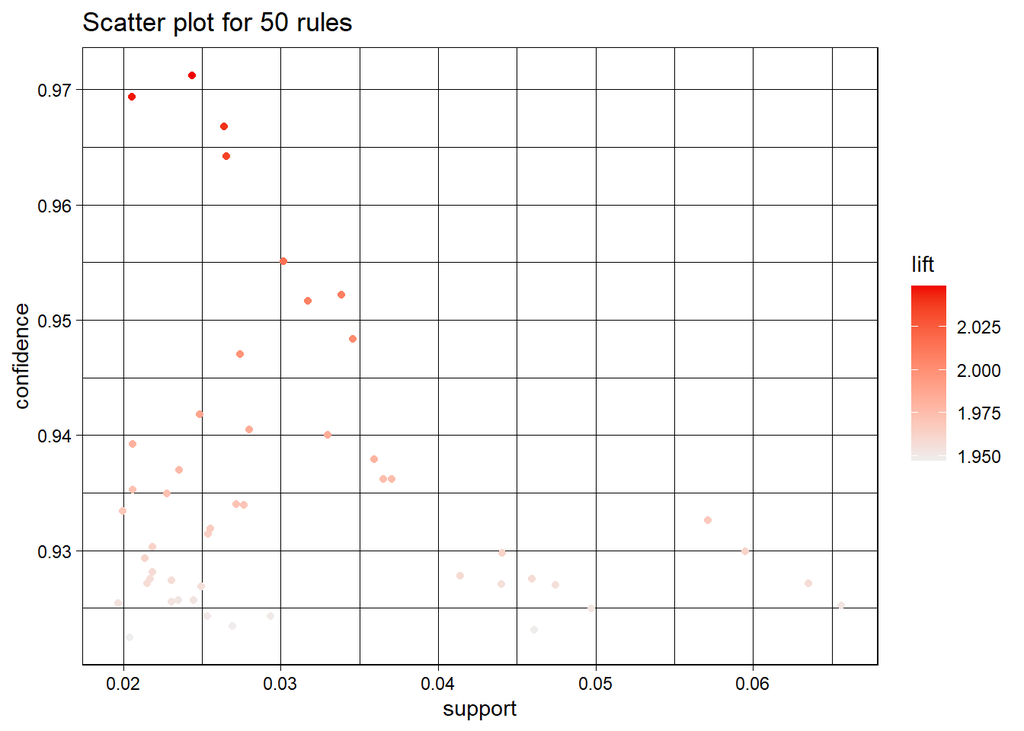

```r
plot(head(rules_yes_nonred, 50), method = "scatterplot", measure = c("support", "confidence"), shading = "lift")
```

```r
# Visualización solo de pocas reglas para evitar un grafo ilegible.
plot(head(rules_yes_nonred, 15), method = "graph", engine = "htmlwidget")
```

[interactive chart not shown]

**Interpretación de los resultados.**

El algoritmo Apriori generó 4.743 reglas con consecuente `deposit=yes`, de las cuales 1.147 son no redundantes. Las reglas con mayor lift (en torno a 2,0–2,05) combinan de forma consistente tres elementos clave: éxito en campañas anteriores (`poutcome=success`), duración de llamada media-larga (`duration_group=medium_long`) y ausencia de hipoteca (`housing=no`).

La regla con mayor lift identifica clientes sin hipoteca, contactados por teléfono móvil, con éxito previo en campaña y llamada de duración media-larga: la confianza supera el 97% y el lift roza 2,05, lo que significa que ese perfil contrató depósito con aproximadamente el doble de probabilidad que la media del dataset.

Desde el punto de vista operativo, el hallazgo más accionable es que `poutcome=success` aparece en prácticamente todas las reglas de alto lift. Clientes que ya respondieron positivamente en campañas previas deben ser priorizados en futuras campañas, independientemente de otras características. A este segmento se le suman como factores reforzadores: ausencia de hipoteca, ausencia de préstamo personal, contacto por móvil, y pertenecer a ciertos grupos educativos o demográficos.

Las reglas son asociaciones descriptivas, no relaciones causales: no se puede concluir que “contactar por móvil causa la contratación”, sino que ese canal aparece asociado con perfiles de mayor propensión. El gráfico de dispersión (soporte vs. confianza, sombreado por lift) confirma que las reglas de mayor lift se concentran en soportes moderados: son patrones específicos pero no marginales.

# 8 8. Clustering de clientes

## 8.1 8.1 K-means sobre variables numéricas escaladas

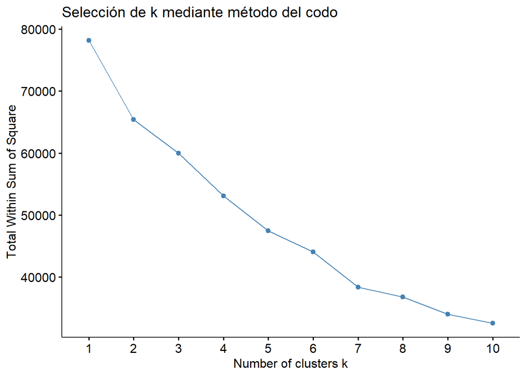

```r
fviz_nbclust(as.data.frame(rep_numeric_scaled), kmeans, method = "wss") +
  labs(title = "Selección de k mediante método del codo")
```

```r
set.seed(123)
k_num <- 3
km <- kmeans(rep_numeric_scaled, centers = k_num, nstart = 25)

bank_clusters_km <- bank_prep |>
  mutate(cluster_kmeans = factor(km$cluster))

bank_clusters_km |>
  count(cluster_kmeans, deposit) |>
  group_by(cluster_kmeans) |>
  mutate(prop = n / sum(n)) |>
  ungroup()
```

```
## # A tibble: 6 × 4
##   cluster_kmeans deposit     n  prop
##   <fct>          <fct>   <int> <dbl>
## 1 1              no        770 0.357
## 2 1              yes      1389 0.643
## 3 2              no       2796 0.656
## 4 2              yes      1468 0.344
## 5 3              no       2307 0.487
## 6 3              yes      2432 0.513
```

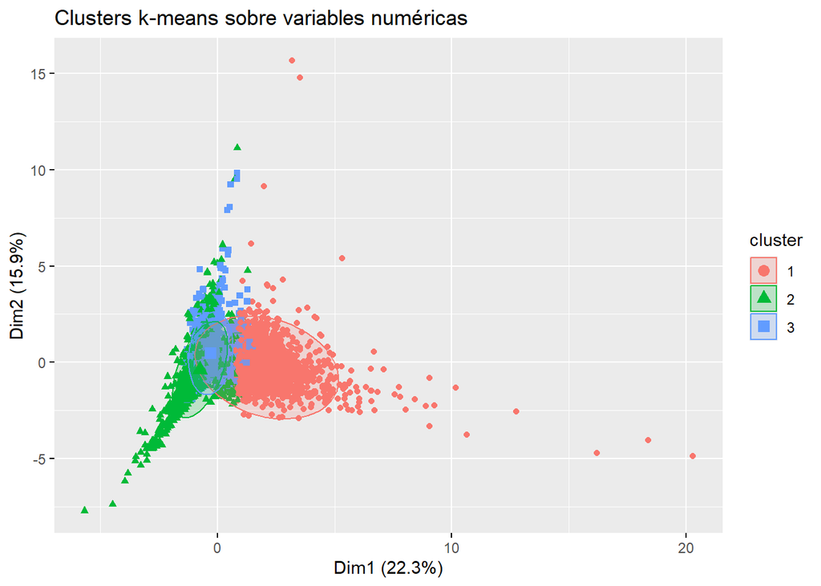

```r
fviz_cluster(km, data = rep_numeric_scaled, geom = "point", ellipse.type = "norm") +
  labs(title = "Clusters k-means sobre variables numéricas")
```

```r
bank_clusters_km |>
  group_by(cluster_kmeans) |>
  summarise(
    n = n(),
    deposit_rate = mean(deposit == "yes"),
    age_mean = mean(age),
    balance_mean = mean(balance),
    duration_mean = mean(duration),
    campaign_mean = mean(campaign),
    previous_mean = mean(previous),
    .groups = "drop"
  )
```

```
## # A tibble: 3 × 8
##   cluster_kmeans     n deposit_rate age_mean balance_mean duration_mean
##   <fct>          <int>        <dbl>    <dbl>        <dbl>         <dbl>
## 1 1               2159        0.643     42.0        1799.          349.
## 2 2               4264        0.344     40.8        1613.          294.
## 3 3               4739        0.513     41.3        1329.          453.
## # ℹ 2 more variables: campaign_mean <dbl>, previous_mean <dbl>
```

## 8.2 8.2 PAM con distancia de Gower

```r
set.seed(123)
k_gower <- 3

pam_gower <- pam(dist_gower, k = k_gower, diss = TRUE)

bank_gower_clusters <- X_mixed_sample |>
  mutate(cluster_gower = factor(pam_gower$clustering))

bank_gower_clusters |>
  count(cluster_gower, deposit) |>
  group_by(cluster_gower) |>
  mutate(prop = n / sum(n)) |>
  ungroup()
```

```
## # A tibble: 6 × 4
##   cluster_gower deposit     n  prop
##   <fct>         <fct>   <int> <dbl>
## 1 1             no        188 0.398
## 2 1             yes       284 0.602
## 3 2             no        406 0.694
## 4 2             yes       179 0.306
## 5 3             no        199 0.449
## 6 3             yes       244 0.551
```

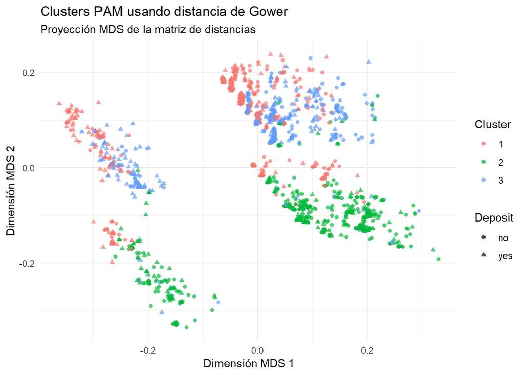

```r
gower_mds <- cmdscale(dist_gower, k = 2)

gower_plot <- tibble(
  Dim1 = gower_mds[, 1],
  Dim2 = gower_mds[, 2],
  cluster_gower = factor(pam_gower$clustering),
  deposit = X_mixed_sample$deposit
)

ggplot(gower_plot, aes(Dim1, Dim2, color = cluster_gower, shape = deposit)) +
  geom_point(alpha = 0.7) +
  labs(
    title = "Clusters PAM usando distancia de Gower",
    subtitle = "Proyección MDS de la matriz de distancias",
    x = "Dimensión MDS 1",
    y = "Dimensión MDS 2",
    color = "Cluster",
    shape = "Deposit"
  ) +
  theme_minimal()
```

```r
bank_gower_clusters |>
  group_by(cluster_gower) |>
  summarise(
    n = n(),
    deposit_rate = mean(deposit == "yes"),
    age_mean = mean(age),
    balance_mean = mean(balance),
    most_common_job = names(sort(table(job), decreasing = TRUE))[1],
    most_common_education = names(sort(table(education), decreasing = TRUE))[1],
    housing_yes = mean(housing == "yes"),
    loan_yes = mean(loan == "yes"),
    .groups = "drop"
  )
```

```
## # A tibble: 3 × 9
##   cluster_gower     n deposit_rate age_mean balance_mean most_common_job
##   <fct>         <int>        <dbl>    <dbl>        <dbl> <chr>
## 1 1               472        0.602     35.2        1597. management
## 2 2               585        0.306     39.8        1177. blue-collar
## 3 3               443        0.551     49.9        1604. technician
## # ℹ 3 more variables: most_common_education <chr>, housing_yes <dbl>,
## #   loan_yes <dbl>
```

**Interpretación de los resultados.**

**K-means (variables numéricas).** El método del codo sugiere k = 3 como punto razonable de inflexión. Los tres clusters resultantes muestran tasas de contratación claramente diferenciadas:

- **Cluster 1** (n = 2.159): tasa de depósito del **64,3%**, con balance promedio más alto (~1.799 €), edad media de 42 años y duración de llamada corta (~349 s). Es el segmento más valioso en términos de conversión.
- **Cluster 2** (n = 4.264): tasa de depósito del **34,4%**, con balance intermedio (~1.613 €) y duración de llamada más corta (~294 s). Es el segmento de menor propensión.
- **Cluster 3** (n = 4.739): tasa de depósito del **51,3%**, con balance más bajo (~1.329 €) pero mayor duración de llamada (~453 s). Sugiere clientes que requieren más tiempo de persuasión pero con resultados medios-altos.

**PAM con Gower (variables mixtas).** Al incorporar información categórica, el perfil de los clusters cambia significativamente:

- **Cluster 1** (n = 472, tasa 60,2%): clientes jóvenes (~35 años), con ocupación predominante en management y educación terciaria. Perfil de mayor valor y conversión.
- **Cluster 2** (n = 585, tasa 30,6%): clientes de mediana edad (~40 años), trabajadores blue-collar. Segmento de menor propensión al depósito.
- **Cluster 3** (n = 443, tasa 55,1%): clientes mayores (~50 años), principalmente technicians. Propensión media-alta, segmento con potencial sin explotar.

La diferencia entre ambos enfoques ilustra cómo la elección de la representación y la métrica de distancia afecta directamente a la segmentación. PAM con Gower es más coherente para datos de clientes bancarios al incorporar variables como ocupación y nivel educativo.

# 9 9. PCA y biplots

## 9.1 9.1 PCA sobre variables numéricas

```r
pca_num <- prcomp(rep_numeric_scaled, center = FALSE, scale. = FALSE)
summary(pca_num)
```

```
## Importance of components:
##                           PC1    PC2   PC3    PC4    PC5    PC6     PC7
## Standard deviation     1.2490 1.0555 1.055 0.9887 0.9414 0.9267 0.70019
## Proportion of Variance 0.2229 0.1592 0.159 0.1396 0.1266 0.1227 0.07004
## Cumulative Proportion  0.2229 0.3820 0.541 0.6807 0.8073 0.9300 1.00000
```

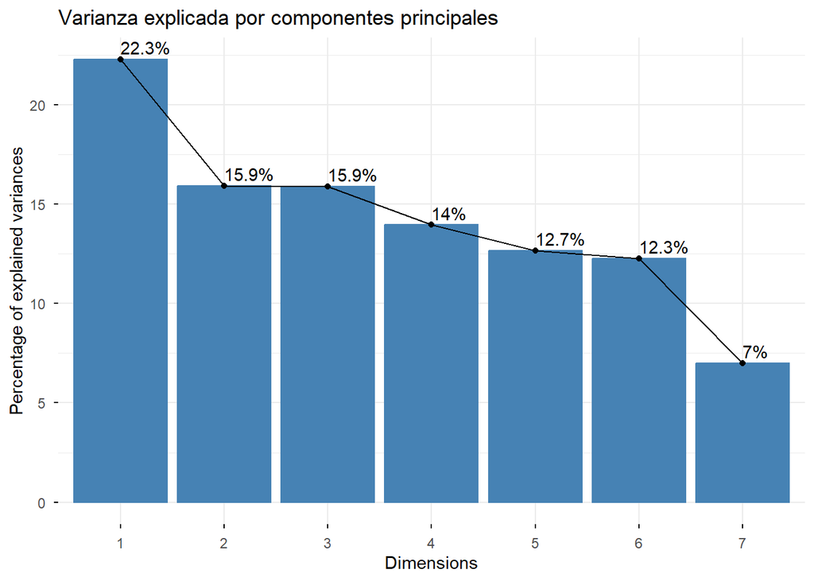

```r
fviz_eig(pca_num, addlabels = TRUE) +
  labs(title = "Varianza explicada por componentes principales")
```

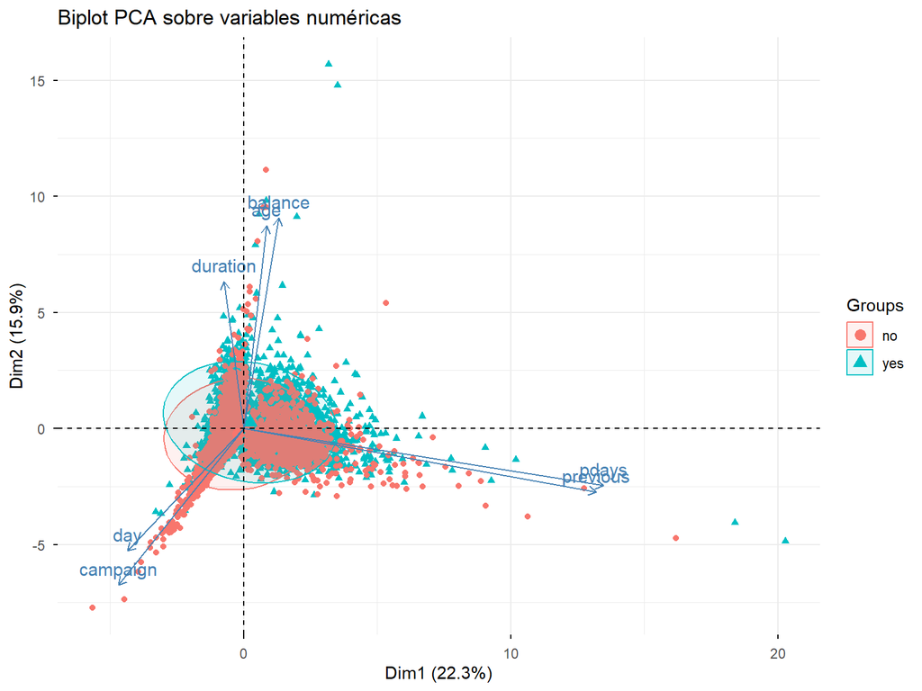

```r
fviz_pca_biplot(
  pca_num,
  geom.ind = "point",
  habillage = bank_prep$deposit,
  addEllipses = TRUE,
  label = "var"
) +
  labs(title = "Biplot PCA sobre variables numéricas")
```

```r
loadings_num <- pca_num$rotation |>
  as.data.frame() |>
  rownames_to_column("variable")

loadings_num
```

```
##   variable         PC1        PC2         PC3        PC4         PC5
## 1      age  0.04271719  0.5170379 -0.45586358 -0.2441988  0.65952721
## 2  balance  0.06595575  0.5365909 -0.45375348  0.0316461 -0.66877055
## 3      day -0.21736953 -0.3121179 -0.51580468  0.3562778 -0.13503350
## 4 duration -0.03712195  0.3749704  0.23068590  0.8685957  0.20954191
## 5 campaign -0.23447939 -0.3991519 -0.48199527  0.1716123  0.22916607
## 6    pdays  0.67403157 -0.1454749 -0.08630122  0.1061379  0.02057976
## 7 previous  0.66022601 -0.1619766 -0.16510113  0.1313662  0.05183963
##           PC6          PC7
## 1 -0.16723666  0.021404928
## 2  0.23096833  0.015029468
## 3 -0.66638277  0.006674178
## 4  0.07992169  0.007026885
## 5  0.68257758  0.074146654
## 6 -0.02523581  0.710454056
## 7  0.04102510 -0.699270570
```

## 9.2 9.2 PCA sobre representación dummy

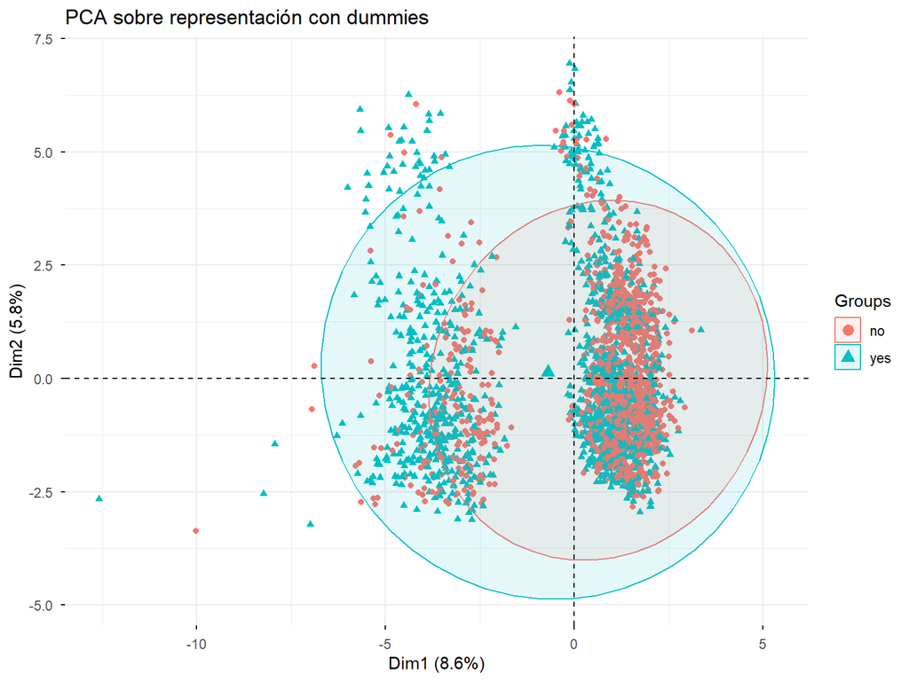

```r
# PCA sobre muestra para evitar un cálculo demasiado pesado.
set.seed(123)
idx_pca_dummy <- sample(seq_len(nrow(rep_dummy)), size = min(2500, nrow(rep_dummy)))
X_dummy_pca <- rep_dummy |>
  select(-deposit) |>
  slice(idx_pca_dummy)
y_dummy_pca <- rep_dummy |>
  slice(idx_pca_dummy) |>
  pull(deposit)

pca_dummy <- prcomp(X_dummy_pca, center = FALSE, scale. = FALSE)

fviz_pca_ind(
  pca_dummy,
  geom.ind = "point",
  habillage = y_dummy_pca,
  addEllipses = TRUE
) +
  labs(title = "PCA sobre representación con dummies")
```

**Interpretación de los resultados.**

El PCA sobre variables numéricas muestra que ninguna componente acumula más del 23% de la varianza por sí sola, y se necesitan las 5 primeras componentes para superar el 80% de varianza explicada acumulada. Esto refleja que la información está repartida entre variables y que no hay una única dimensión dominante.

En los loadings, PC1 está dominada por `pdays` y `previous` (con cargas similares en torno a 0,67), variables de contacto previo. PC2 recoge principalmente `age` y `balance` (cargas ~0,52 y ~0,54). La variable `duration` tiene su mayor carga en PC4.

En el PCA sobre representación dummy el solapamiento entre clases sigue siendo visible, lo que confirma que la estructura informativa está distribuida en muchas dimensiones y no se captura fácilmente con proyecciones lineales de baja dimensión. Este resultado no implica que los modelos predictivos vayan a tener mal rendimiento: simplemente la frontera de decisión no es lineal en este espacio.

# 10 10. Clasificación supervisada

Se entrenan varios modelos para predecir `deposit`. Se comparan dos escenarios:

1. **Con `duration`**: útil para entender la campaña una vez realizada la llamada.
2. **Sin `duration`**: más realista si el banco quiere priorizar clientes antes de llamar.

La variable `duration` mide la duración de la llamada. Por tanto, puede ser muy predictiva, pero no siempre estaría disponible antes de decidir a qué cliente llamar. Por eso se comparan ambos escenarios.

## 10.1 10.1 División train/test

```r
set.seed(123)

split_bank <- initial_split(
  bank_prep |> select(-pdays_clean),
  prop = 0.8,
  strata = deposit
)

train_bank <- training(split_bank)
test_bank  <- testing(split_bank)

count(train_bank, deposit) |> mutate(prop = n / sum(n))
```

```
## # A tibble: 2 × 3
##   deposit     n  prop
##   <fct>   <int> <dbl>
## 1 no       4698 0.526
## 2 yes      4231 0.474
```

```r
count(test_bank, deposit) |> mutate(prop = n / sum(n))
```

```
## # A tibble: 2 × 3
##   deposit     n  prop
##   <fct>   <int> <dbl>
## 1 no       1175 0.526
## 2 yes      1058 0.474
```

## 10.2 10.2 Funciones auxiliares

```r
classification_metrics <- metric_set(accuracy, roc_auc, sens, spec)

fit_evaluate_model <- function(model_spec, recipe_obj, train_data, test_data, model_name) {
  wf <- workflow() |>
    add_model(model_spec) |>
    add_recipe(recipe_obj)

  fitted <- fit(wf, data = train_data)

  preds_class <- predict(fitted, test_data, type = "class")
  preds_prob  <- predict(fitted, test_data, type = "prob")

  results <- bind_cols(
    test_data |> select(deposit),
    preds_class,
    preds_prob
  )

  metrics <- classification_metrics(
    results,
    truth = deposit,
    estimate = .pred_class,
    .pred_yes,
    event_level = "second"
  ) |>
    mutate(model = model_name)

  list(
    fitted = fitted,
    predictions = results,
    metrics = metrics
  )
}
```

## 10.3 10.3 Recetas de preprocesado

```r
recipe_with_duration <- recipe(deposit ~ ., data = train_bank) |>
  step_dummy(all_nominal_predictors()) |>
  step_zv(all_predictors()) |>
  step_normalize(all_numeric_predictors())

train_bank_no_duration <- train_bank |> select(-duration, -duration_group)
test_bank_no_duration  <- test_bank |> select(-duration, -duration_group)

recipe_without_duration <- recipe(deposit ~ ., data = train_bank_no_duration) |>
  step_dummy(all_nominal_predictors()) |>
  step_zv(all_predictors()) |>
  step_normalize(all_numeric_predictors())
```

**Nota metodológica.** No se utiliza `step_unknown()` porque varias variables categóricas ya contienen el nivel `"unknown"` como categoría propia del dataset (`job`, `education`, `contact`, `poutcome`). En este trabajo se interpreta `"unknown"` como un nivel informativo y no como un valor perdido real.

## 10.4 10.4 Modelos candidatos

```r
log_spec <- logistic_reg() |>
  set_engine("glm") |>
  set_mode("classification")

tree_spec <- decision_tree(
  cost_complexity = 0.01,
  tree_depth = 6,
  min_n = 20
) |>
  set_engine("rpart") |>
  set_mode("classification")

rf_spec <- rand_forest(
  trees = 300,
  mtry = 8,
  min_n = 10
) |>
  set_engine("ranger", importance = "impurity") |>
  set_mode("classification")

svm_spec <- svm_rbf(
  cost = 1,
  rbf_sigma = 0.05
) |>
  set_engine("kernlab") |>
  set_mode("classification")

models_candidates <- list(
  logistic = log_spec,
  tree = tree_spec,
  random_forest = rf_spec,
  svm_rbf = svm_spec
)
```

## 10.5 10.5 Entrenamiento y evaluación con `duration`

```r
results_with_duration <- map2(
  models_candidates,
  names(models_candidates),
  ~fit_evaluate_model(
    model_spec = .x,
    recipe_obj = recipe_with_duration,
    train_data = train_bank,
    test_data = test_bank,
    model_name = paste0(.y, "_with_duration")
  )
)

metrics_with_duration <- map_dfr(results_with_duration, "metrics")

metrics_with_duration
```

```
## # A tibble: 16 × 4
##    .metric  .estimator .estimate model
##    <chr>    <chr>          <dbl> <chr>
##  1 accuracy binary         0.824 logistic_with_duration
##  2 sens     binary         0.803 logistic_with_duration
##  3 spec     binary         0.842 logistic_with_duration
##  4 roc_auc  binary         0.897 logistic_with_duration
##  5 accuracy binary         0.784 tree_with_duration
##  6 sens     binary         0.867 tree_with_duration
##  7 spec     binary         0.709 tree_with_duration
##  8 roc_auc  binary         0.838 tree_with_duration
##  9 accuracy binary         0.842 random_forest_with_duration
## 10 sens     binary         0.872 random_forest_with_duration
## 11 spec     binary         0.815 random_forest_with_duration
## 12 roc_auc  binary         0.910 random_forest_with_duration
## 13 accuracy binary         0.817 svm_rbf_with_duration
## 14 sens     binary         0.850 svm_rbf_with_duration
## 15 spec     binary         0.787 svm_rbf_with_duration
## 16 roc_auc  binary         0.886 svm_rbf_with_duration
```

## 10.6 10.6 Entrenamiento y evaluación sin `duration`

```r
results_without_duration <- map2(
  models_candidates,
  names(models_candidates),
  ~fit_evaluate_model(
    model_spec = .x,
    recipe_obj = recipe_without_duration,
    train_data = train_bank_no_duration,
    test_data = test_bank_no_duration,
    model_name = paste0(.y, "_without_duration")
  )
)

metrics_without_duration <- map_dfr(results_without_duration, "metrics")

metrics_without_duration
```

```
## # A tibble: 16 × 4
##    .metric  .estimator .estimate model
##    <chr>    <chr>          <dbl> <chr>
##  1 accuracy binary         0.713 logistic_without_duration
##  2 sens     binary         0.595 logistic_without_duration
##  3 spec     binary         0.820 logistic_without_duration
##  4 roc_auc  binary         0.762 logistic_without_duration
##  5 accuracy binary         0.657 tree_without_duration
##  6 sens     binary         0.538 tree_without_duration
##  7 spec     binary         0.763 tree_without_duration
##  8 roc_auc  binary         0.701 tree_without_duration
##  9 accuracy binary         0.726 random_forest_without_duration
## 10 sens     binary         0.620 random_forest_without_duration
## 11 spec     binary         0.822 random_forest_without_duration
## 12 roc_auc  binary         0.784 random_forest_without_duration
## 13 accuracy binary         0.701 svm_rbf_without_duration
## 14 sens     binary         0.583 svm_rbf_without_duration
## 15 spec     binary         0.807 svm_rbf_without_duration
## 16 roc_auc  binary         0.748 svm_rbf_without_duration
```

## 10.7 10.7 Comparación global de modelos

```r
all_metrics <- bind_rows(
  metrics_with_duration,
  metrics_without_duration
)

all_metrics |>
  arrange(.metric, desc(.estimate))
```

```
## # A tibble: 32 × 4
##    .metric  .estimator .estimate model
##    <chr>    <chr>          <dbl> <chr>
##  1 accuracy binary         0.842 random_forest_with_duration
##  2 accuracy binary         0.824 logistic_with_duration
##  3 accuracy binary         0.817 svm_rbf_with_duration
##  4 accuracy binary         0.784 tree_with_duration
##  5 accuracy binary         0.726 random_forest_without_duration
##  6 accuracy binary         0.713 logistic_without_duration
##  7 accuracy binary         0.701 svm_rbf_without_duration
##  8 accuracy binary         0.657 tree_without_duration
##  9 roc_auc  binary         0.910 random_forest_with_duration
## 10 roc_auc  binary         0.897 logistic_with_duration
## # ℹ 22 more rows
```

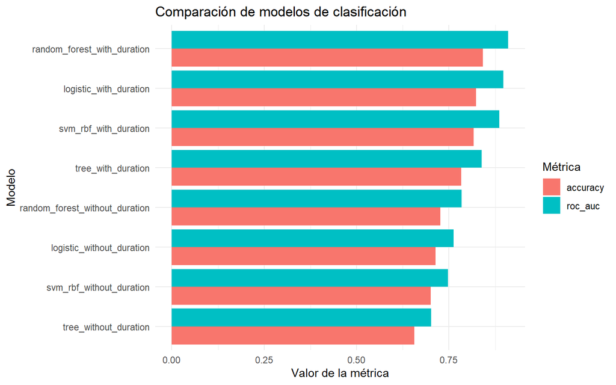

```r
all_metrics |>
  filter(.metric %in% c("accuracy", "roc_auc")) |>
  ggplot(aes(x = reorder(model, .estimate), y = .estimate, fill = .metric)) +
  geom_col(position = "dodge") +
  coord_flip() +
  labs(
    title = "Comparación de modelos de clasificación",
    x = "Modelo",
    y = "Valor de la métrica",
    fill = "Métrica"
  ) +
  theme_minimal()
```

**Interpretación de los resultados.**

Los resultados muestran una diferencia notable y sistemática entre los escenarios con y sin `duration`:

**Con `duration`:**

| Modelo | Accuracy | ROC-AUC | Sensibilidad | Especificidad |
| --- | --- | --- | --- | --- |
| Random Forest | 0,842 | **0,910** | 0,872 | 0,815 |
| Logística | 0,824 | 0,897 | 0,803 | 0,842 |
| SVM RBF | 0,817 | 0,886 | 0,850 | 0,787 |
| Árbol decisión | 0,784 | 0,838 | 0,867 | 0,709 |

**Sin `duration`:**

| Modelo | Accuracy | ROC-AUC | Sensibilidad | Especificidad |
| --- | --- | --- | --- | --- |
| Random Forest | 0,726 | **0,784** | 0,620 | 0,822 |
| Logística | 0,713 | 0,762 | 0,595 | 0,820 |
| SVM RBF | 0,701 | 0,748 | 0,583 | 0,807 |
| Árbol decisión | 0,657 | 0,701 | 0,538 | 0,763 |

La caída al eliminar `duration` es pronunciada: el ROC-AUC del mejor modelo pasa de 0,91 a 0,78. Esto confirma que `duration` actúa como un proxy muy fuerte de la predisposición del cliente (las llamadas más largas ocurren cuando el cliente está interesado), pero al no ser observable antes de la llamada, su inclusión en un modelo de priorización previa sería metodológicamente incorrecta.

**Random Forest** es el mejor modelo en ambos escenarios, tanto en accuracy como en ROC-AUC. Para una decisión operativa realista de priorización previa al contacto, el Random Forest sin `duration` (ROC-AUC = 0,784) es el modelo más adecuado.

# 11 11. Conexión predictiva-prescriptiva: priorización de clientes

Una predicción solo se convierte en decisión si se traduce en una acción. Como ejemplo simple, se puede estimar la probabilidad de contratación y ordenar clientes por probabilidad esperada.

```r
# Usamos Random Forest sin duration como ejemplo más realista para priorización previa a la llamada.
rf_no_duration <- results_without_duration$random_forest$fitted

client_scores <- predict(rf_no_duration, test_bank_no_duration, type = "prob") |>
  bind_cols(test_bank_no_duration |> select(deposit, age, job, marital, education, balance, housing, loan, poutcome)) |>
  arrange(desc(.pred_yes))

client_scores |> head(15)
```

```
## # A tibble: 15 × 11
##    .pred_no .pred_yes deposit   age job        marital education balance housing
##       <dbl>     <dbl> <fct>   <dbl> <fct>      <fct>   <fct>       <dbl> <fct>
##  1   0.0253     0.975 yes        33 management single  tertiary      935 no
##  2   0.0297     0.970 yes        34 management divorc… tertiary     2240 no
##  3   0.0310     0.969 yes        62 management married tertiary     3371 no
##  4   0.0314     0.969 no         68 retired    married tertiary     2820 no
##  5   0.0331     0.967 yes        51 management married tertiary      346 no
##  6   0.0333     0.967 yes        47 management single  tertiary       86 no
##  7   0.0334     0.967 yes        60 admin.     married secondary    3735 no
##  8   0.0350     0.965 yes        47 admin.     married secondary    3676 no
##  9   0.0354     0.965 yes        36 management single  tertiary      538 no
## 10   0.0364     0.964 yes        47 management married tertiary      288 no
## 11   0.0382     0.962 yes        36 management married tertiary      925 no
## 12   0.0394     0.961 yes        31 management single  tertiary      924 no
## 13   0.0396     0.960 yes        57 blue-coll… married primary      3109 no
## 14   0.0401     0.960 yes        24 student    single  tertiary      235 no
## 15   0.0409     0.959 yes        58 retired    married primary       565 no
## # ℹ 2 more variables: loan <fct>, poutcome <fct>
```

**Lectura de negocio de los resultados.**

En una implementación real, este ranking debe cruzarse con el valor económico esperado del depósito, el coste marginal de la llamada y las restricciones de capacidad del equipo comercial, para construir una política de priorización completa.

# 12 12. Conclusiones de negocio

## 12.1 12.1 Conclusión descriptiva

El dataset presenta una distribución casi equilibrada entre clientes que contrataron depósito (47,4%) y los que no (52,6%), lo que facilita el aprendizaje supervisado sin necesidad de técnicas de balanceo agresivas. Las variables numéricas más relevantes para la contratación son `duration`, `balance` y `previous`: los clientes con llamadas más largas, mayor saldo y contacto previo muestran tasas de conversión claramente superiores. Entre las variables categóricas, `poutcome=success` es el predictor de mayor poder discriminante: clientes con éxito en campañas anteriores duplican la tasa de contratación respecto a la media. Además, el mes de contacto y el canal (`contact=cellular`) también muestran diferencias apreciables.

## 12.2 12.2 Conclusión sobre reglas de asociación

Las reglas de asociación confirman que el perfil de mayor propensión combina éxito previo (`poutcome=success`), llamada de duración media-larga, ausencia de hipoteca y contacto por móvil. Las reglas de mayor lift (≈2,05) alcanzan confianzas superiores al 97%, lo que las convierte en criterios de filtrado muy fiables para segmentar la base de clientes antes de una campaña. La implicación práctica es directa: **los clientes con historial de éxito previo y sin cargas hipotecarias deben ser el primer segmento a contactar** en cualquier campaña futura.

## 12.5 12.5 Conclusión predictiva

Random Forest es el mejor modelo en ambos escenarios (con y sin `duration`). Con `duration`, alcanza ROC-AUC = 0,910 y accuracy = 0,842. Sin `duration` —el escenario operativamente válido para priorización previa al contacto— el ROC-AUC desciende a 0,784 y la accuracy a 0,726. La caída de aproximadamente 12 puntos en ROC-AUC al eliminar `duration` confirma que esta variable actúa como proxy del interés del cliente durante la llamada, y que su exclusión es metodológicamente necesaria para un sistema de scoring previo al contacto.

## 12.6 12.6 Recomendación final para el banco

El análisis permite diseñar una política de priorización de campañas en tres pasos:

1. **Filtrado por reglas de negocio:** excluir clientes con historial de rechazo previo y sin contacto anterior. Priorizar clientes con `poutcome=success`.
2. **Scoring con Random Forest (sin `duration`):** ordenar el resto de la base de clientes por probabilidad estimada de contratar. El modelo sin `duration` es el adecuado para decisiones previas al contacto.
3. **Segmentación diferenciada:** usar los clusters PAM-Gower para adaptar el mensaje comercial y el canal de contacto (móvil vs. teléfono fijo) a cada segmento.

Esta combinación de análisis descriptivo, reglas de asociación, clustering y clasificación supervisada proporciona una base analítica sólida para mejorar la eficiencia de futuras campañas, reduciendo el número de contactos necesarios para conseguir la misma tasa de conversión.

# 13 13. Limitaciones

**Fuga de información por `duration`.** La variable `duration` —duración de la llamada en segundos— es un predictor muy potente, pero su valor solo se conoce al finalizar la llamada, no antes. Incluirla en un modelo de scoring previo al contacto introduce fuga de información (*data leakage*): el modelo aprendería a predecir usando información que, en producción, no estaría disponible en el momento de la decisión. Por eso se entrenaron y evaluaron modelos en ambos escenarios, y el recomendado para uso operativo es siempre el modelo sin `duration`.

**Causalidad vs. asociación.** Las reglas de asociación y los análisis descriptivos identifican patrones de coocurrencia, no relaciones causales. El hecho de que `poutcome=success` esté fuertemente asociado con `deposit=yes` no implica que cambiar el resultado de la campaña anterior (algo imposible) aumente la probabilidad de contratación. La causalidad requeriría un diseño experimental o métodos de inferencia causal que van más allá del alcance de este proyecto.

**Representatividad de los datos.** El dataset recoge una campaña concreta en un contexto histórico específico (período, país, tipo de producto bancario). La extrapolación directa de los modelos a campañas futuras, a otros productos o a otros mercados debe hacerse con cautela y validarse con datos nuevos antes de su uso en producción.

**Hiperparámetros fijados sin validación cruzada.** Los modelos se entrenaron con hiperparámetros fijados de antemano (p. ej., `mtry = 8`, `trees = 300` en Random Forest; `cost = 1`, `rbf_sigma = 0.05` en SVM). Un proceso de búsqueda sistemática con validación cruzada podría mejorar las métricas, especialmente en el escenario sin `duration`, donde el margen de mejora es mayor.

**Clustering sin validación de estabilidad.** El número de clusters (k = 3) se eligió usando el método del codo, que es visual y subjetivo. No se realizó un análisis de estabilidad de los clusters (p. ej., bootstrap, índice de Silhouette comparativo entre distintos k) ni se validó la coherencia de los segmentos con criterios de negocio externos.

**Ausencia de valor económico.** El análisis predice la probabilidad de contratación, pero no incorpora el valor económico del depósito ni el coste marginal de cada contacto. Una política de priorización óptima desde el punto de vista del negocio debería maximizar el valor esperado neto, no simplemente la probabilidad de conversión. Esta extensión requeriría información adicional sobre rentabilidad por cliente que no está disponible en el dataset.

**Categorías `unknown` tratadas como nivel informativo.** Las variables `job`, `education`, `contact` y `poutcome` contienen la categoría `unknown`. En este trabajo se trata como un nivel más, lo que puede ser razonable si `unknown` se correlaciona con algún patrón de comportamiento (p. ej., clientes que no quisieron revelar su ocupación). Sin embargo, en un proyecto de producción sería conveniente analizar con más detalle si `unknown` encubre valores perdidos sistemáticos o si es realmente informativo.